# Wireless link characteristics

- 信号强度下降：无线电信号在物质中传播时会衰减（路径损耗）
- 来自其他来源的干扰：无线网络频率（如2.4GHz）被许多设备共享（如WiFi、手机、电机）：干扰
- 多径传播：无线电信号在物体上反射，到达目的地的时间略有不同
- 使整个（甚至是点对点）无线链路的通信更加 "困难"
- `SNR`：signal-to-noise ratio
  - 更大的信噪比--更容易从噪声中提取信号（一个 "好东西"）
  - 信噪比与 `BER`: Bit Error Rat 误码率 的权衡
    - 给定物理层：增加功率->增加信噪比->减少误码率
    - 给定信噪比：选择满足误码率要求的物理层，提供最高的吞吐量
    - 信噪比可能随移动性而变化：动态适应物理层（调制技术、传输速率）
      1. 信噪比下降，误码率随着节点远离基站而增加
      2. 当误码率变得太高时，切换到较低的传输速率，但误码率较低。

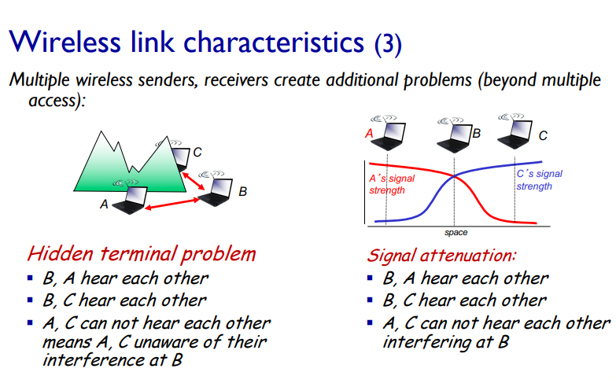

- - Hidden terminal problem
  - Signal attenuation
  - Exposed Terminals
- 802.11: passive/active scanning

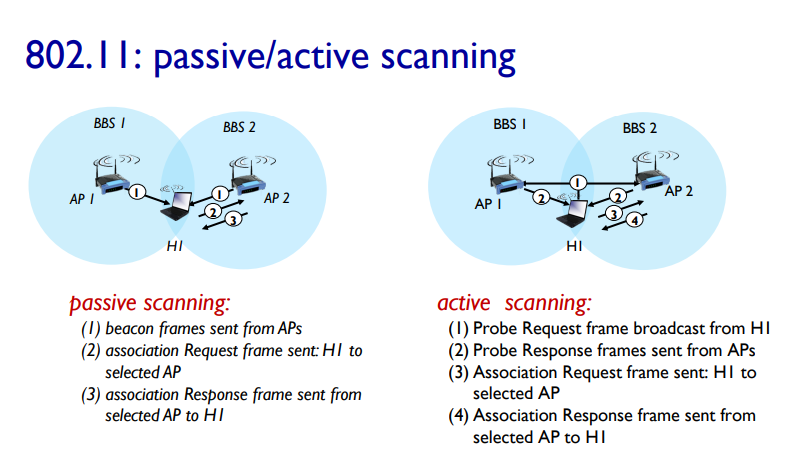

  - 被动扫描:
    - (1) 从APs发送的信标帧
    - (2) 发送关联请求帧。H1到选定的AP
    - (3) 联想响应帧从选定的AP发送至H1
  - 主动扫描:
    - (1) 从H1广播的探针请求帧
    - (2) 从AP发送的探测响应帧
    - (3) 发送关联请求帧。H1到选定的AP
    - (4) 协会响应帧从选定的AP发送至H1
- IEEE 802.11：multiple access
  - 避免碰撞。2个以上的节点在同一时间进行传输
  - 802.11：CSMA--传输前的感应
    - 不要与另一个节点正在进行的传输发生碰撞
  - 802.11：没有碰撞检测！
    - 难以感知碰撞：发射信号高，由于衰减导致接收信号弱
    - 在任何情况下都不能感知所有的碰撞：隐藏的终端，消退
    - 目标：避免碰撞。`CSMA/CA`：CSMA/CollisionAvoidance
- 多重访问。关键点
  - 没有全局碰撞的概念
    - 不同的接收者听到不同的信号
    - 不同的发送方到达不同的接收方
  - 碰撞发生在接收方，而不是发送方
    - 只关心接收者是否能清楚地听到发送者的声音
    - 如果发送者能听到别人的声音，这并不重要
    - 只要该信号不干扰接收方即可
  - 协议的目标
    - 检测接收方是否能听到发送方
    - 告诉可能干扰接收者的发送者闭嘴

# IEEE 802.11 MAC Protocol: CSMA/CA

- 802.11发送方
  1. 如果DIFS的感知通道空闲，那么发送整个帧（无CD）
  2. 如果感觉到信道繁忙，则开始随机退避时间，当信道空闲时，定时器倒计时，
     - 当定时器过期时，如果没有ACK，则加倍随机退避间隔，重复2
- 802.11接收方
  - 如果帧接收正常，在SIFS后返回ACK（由于隐藏的终端问题需要ACK）
- 避免碰撞（更多）
  - 理念：发送方使用小的保留包为数据帧 "保留 "信道使用权
  - 发送方首先使用CSMA向BS发送小型请求发送（RTS）数据包
    - RTS仍可能相互碰撞（但它们很短）
  - BS广播清晰地发送CTS以回应RTS
  - CTS被所有节点听到
    - 发送者传输数据帧
    - 其他站点推迟传输
    - CTS包含时间

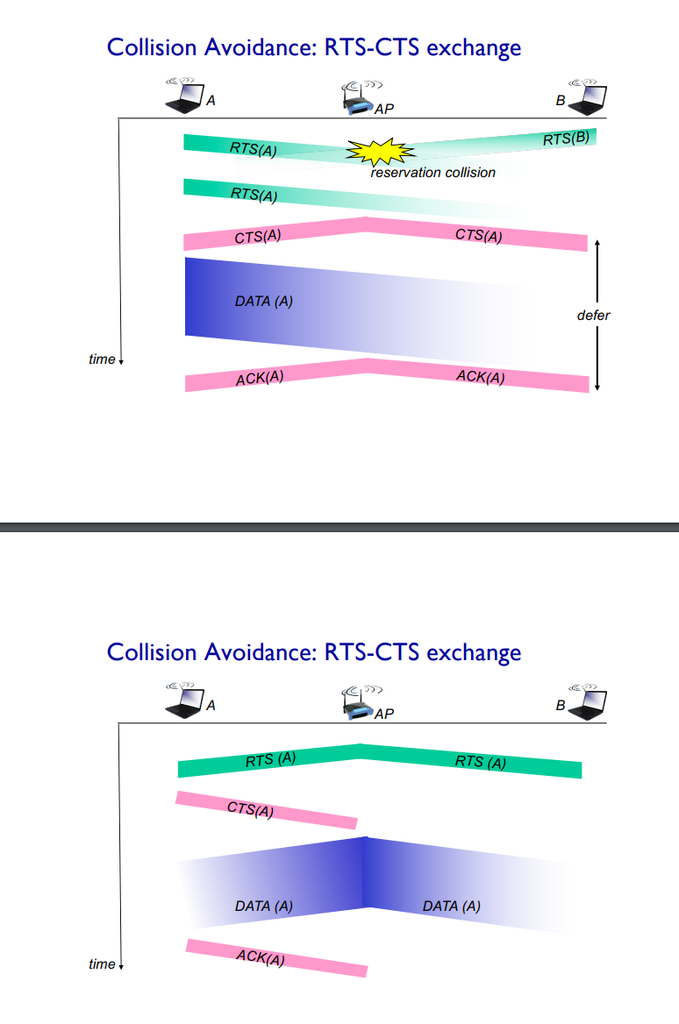

# 802.11 frame: addressing

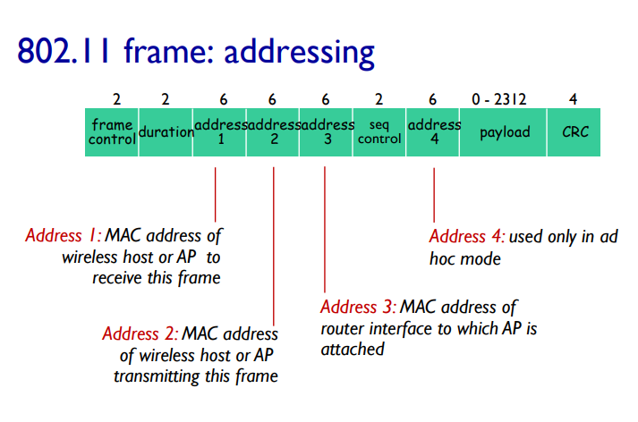

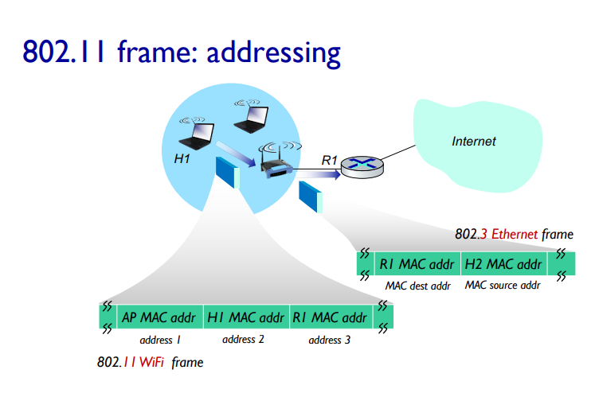

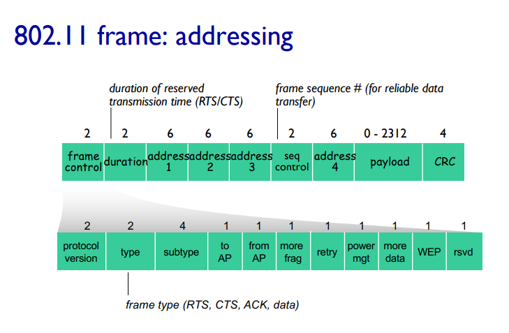